# Results

```r
library(here)
```

```r
library(tidyr)
knitr::opts_chunk$set(fig.pos = "p", dpi = 300)
```

## Terminator effects on gene expression depend on cis-regulatory context

To investigate the context dependence of cis-regulatory regions, we created a library of 120 constructs (Figure @ref(fig:pro-ter-platereader-mCherry-mTurq-norm)A), containing all combinations of 6 promoters (including 5’UTR), 2 coding sequences, and 10 terminators (including 3’UTR). We selected promoters and terminators from native yeast genes spanning a variety of different expression patterns and functions (Table $\ref{tab:terminator-summary-table}$). To choose specific sequence lengths for the terminators of our constructs, we referred to published measurements of median 3’UTR length [@Pelechano2013] because sequences that are necessary and sufficient for efficient transcriptional termination are found upstream of the termination site [@Guo1996c]. For terminators with measured length under 200nt, we used the standardised parts length of 200nt from the YeastFab library. The 2 coding sequences (CDS) expressed mCherry or mTurquoise2 fluorescent proteins, which are bright fluorophores with only 30% amino acid identity [@Shaner2004; @Goedhart2012].

(ref:pro-ter-platereader-mCherry-mTurq-norm-caption) () Design of chimeric reporter constructs with all combinations of 6 promoters, 2 fluorescent proteins, and 10 terminators, on a centromeric plasmid. Terminators highlighted with an asterisk have a terminator length longer than the library standard of 200bp because they have a median 3’UTR length greater than 200bp according to [@Pelechano2013]. () Relative protein abundance from each terminator, normalized to a reference terminator tPGK1 for each matched promoter. The plot shows statistical summaries (mean and standard error) of at least 6 replicates for high-expression promoter data shown in Figure 1A. () RT-qPCR mRNA results targeting the mCherry ORF for pRPS3-mCherry-tRPS3 and pSRO9-mCherry-tSRO9 constructs with differing terminator lengths.

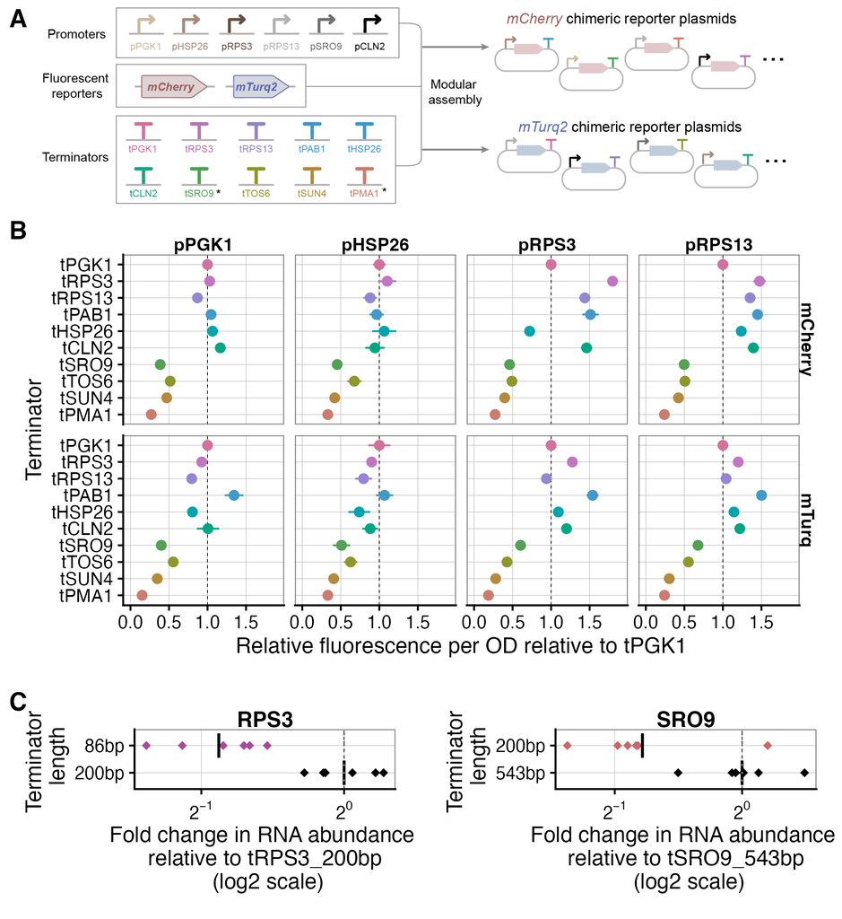

(ref:pro-ter-platereader-mCherry-mTurq-norm-caption)

```r
# NOTE: Currently this figure is included at 80% size so we can see the caption
# Later we will probably want to display the caption on a separate page
knitr::include_graphics(here("results_chapter/figures/pro_ter_swap_protein_and_norm_rna_exp_figure.png"))
```

(ref:tab-1-caption) The common gene name from which the terminator is extracted from is included alongside its systematic name. The median 3’UTR reported by [@Pelechano2013] is a median over the lengths of each distinct isoform they detect. The usage of each motif is signified by S, for promoter-terminator swaps, or M, for motif insertion or deletion. A short summary of the protein function is included.

```r
readr::read_csv(here("results_chapter/data/terminator_summary_table.csv")) %>%
  knitr::kable(format = "latex", align = "c", caption = "(ref:tab-1-caption)") %>%
  kableExtra::column_spec(1, width = "3em") %>%
  kableExtra::column_spec(2, width = "6em") %>%
  kableExtra::column_spec(3, width = "4em") %>%
  kableExtra::column_spec(4, width = "6em") %>%
  kableExtra::column_spec(5, width = "3em") %>%
  kableExtra::column_spec(6, width = "6em") %>%
  kableExtra::row_spec(0, bold = TRUE, font_size = 7) %>%
  kableExtra::kable_styling(font_size = 5)
```

[output not shown]

We further investigated the effects of terminators on mRNA levels by comparing constructs with extended vs truncated terminators. It is known that disrupting the transcription termination signal lowers expression [@Guo1996c; @Shalem2015]. However, standardised parts libraries often assume a fixed terminator length for all genes, which is likely to omit the termination signal for genes with longer terminators. In the case of the YeastFab parts library [@Guo2015] the fixed terminator length is 200bp. We compared a gene with a median 3’UTR length less than 200bp, RPS3 to a gene with a median 3’UTR length greater than 200bp, SRO9. The median length of the native RPS3 3’UTR is 86nt [@Pelechano2013]; truncating the terminator to 86bp or 59bp reduces transcript protein output by almost 2-fold (86bp Fold Change = 0.544, p-value = $2.6 \times 10^{-4}$; 59bp Fold Change = 0.517, p-value = $7.8 \times 10^{-6}$; Figure @ref(fig:pro-ter-platereader-mCherry-mTurq-norm)C). The median length of the native SRO9 3’UTR is 543nt [@Pelechano2013]; extending the terminator length to 543bp increases transcript protein output by almost 2-fold (Fold Change = 0.581, p-value = 0.01; Figure @ref(fig:pro-ter-platereader-mCherry-mTurq-norm)C). This validates our assay’s ability to detect known regulatory signals affecting transcription termination, while highlighting the importance of using well-informed annotations to construct parts libraries for synthetic biology. Note that we used the longer 543bp SRO9 terminator, and a similarly extended 421bp PMA1 terminator, for the main set of constructs (Figure @ref(fig:pro-ter-platereader-mCherry-mTurq-norm)).

## Candidate cis-regulatory elements contribute to transcript decay rates

Next, we investigated the regulatory effects of short CREs, i.e. sequence motifs, contained within terminators or 3’UTRs. First, 69 suitable motifs to test for context dependence were found through a literature search. All were suspected sequence motifs for mRNA binding proteins, several directly associated with proteins involved in mRNA degradation [@Hogan2008; @Shalgi2005; @Cheng2017]. Any motifs that were found in fewer than 6 gene 3’UTRs, as annotated by @Pelechano2013, were removed.

We selected 4 motifs for exploring context dependence: TGTAHMNTA, GTATACCTA, HWNCATTWY, and ATATTC (Table @ref(tab:motif-summary-table)). TGTAHMNTA and GTATACCTA were chosen as they had the largest coefficients amongst significant decay and stability motifs, respectively. HWNCATTWY was chosen due to its statistically significant effect in both datasets and, as it co-occurs with TGTAHMNTA in 68 native 3’UTRs, because it could be used for testing motif interactions. The final selected motif was ATATTC, as it is a statistically significant decay motif in both datasets, and it has been previously shown to lower mRNA abundance when inserted in reporter constructs [@Cheng2017]. Functionally, TGTAHMNTA is the binding motif for Puf4p, and HWNCATTWY is associated with Khd1p/Hek2p-bound transcripts [@Hogan2008]. However, it is not known how ATATTC and GTATACCTA affect mRNA decay.

(ref:tab-2-caption) The first 3 columns hold the consensus sequence for each motif and the exact versions deleted from or inserted into the host terminators. Then, we report the paper from which the motif was selected from; @Hogan2008, @Shalgi2005 or @Cheng2017. Next, each motif’s coefficient and p value given by the linear model predicting either the Chan et al. @Chan2018 or the Sun et al. @Sun2013 half-life datasets are included. Finally, the table includes notes on motif functions.

```r
readr::read_csv(here("results_chapter/data/motif_summary_table.csv")) %>%
  knitr::kable(format = "latex", align = "c", caption = "(ref:tab-2-caption)") %>%
  kableExtra::column_spec(1, width = "6em") %>%
  kableExtra::column_spec(2, width = "5.2em") %>%
  kableExtra::column_spec(3, width = "5.5em") %>%
  kableExtra::column_spec(4, width = "3.5em") %>%
  kableExtra::column_spec(c(6,8), width = "4em") %>%
  kableExtra::column_spec(c(5,7), width = "2.6em") %>%
  kableExtra::column_spec(9, width = "4em") %>%
  kableExtra::row_spec(0, bold = TRUE, font_size = 7) %>%
  kableExtra::kable_styling(font_size = 5)
```

[output not shown]

(ref:hlife-decay-model-caption) () Correlation between the 2 transcript half-lives ($\lambda$), in minutes, reported in the @Chan2018 and @Sun2013 datasets. () Predicted contributions to log2 half-life for chosen motifs in the @Chan2018 and @Sun2013 datasets. () Predicted vs actual transcript half-lives calculated by a linear model of codon and motif usage trained on the @Chan2018 and @Sun2013 datasets.

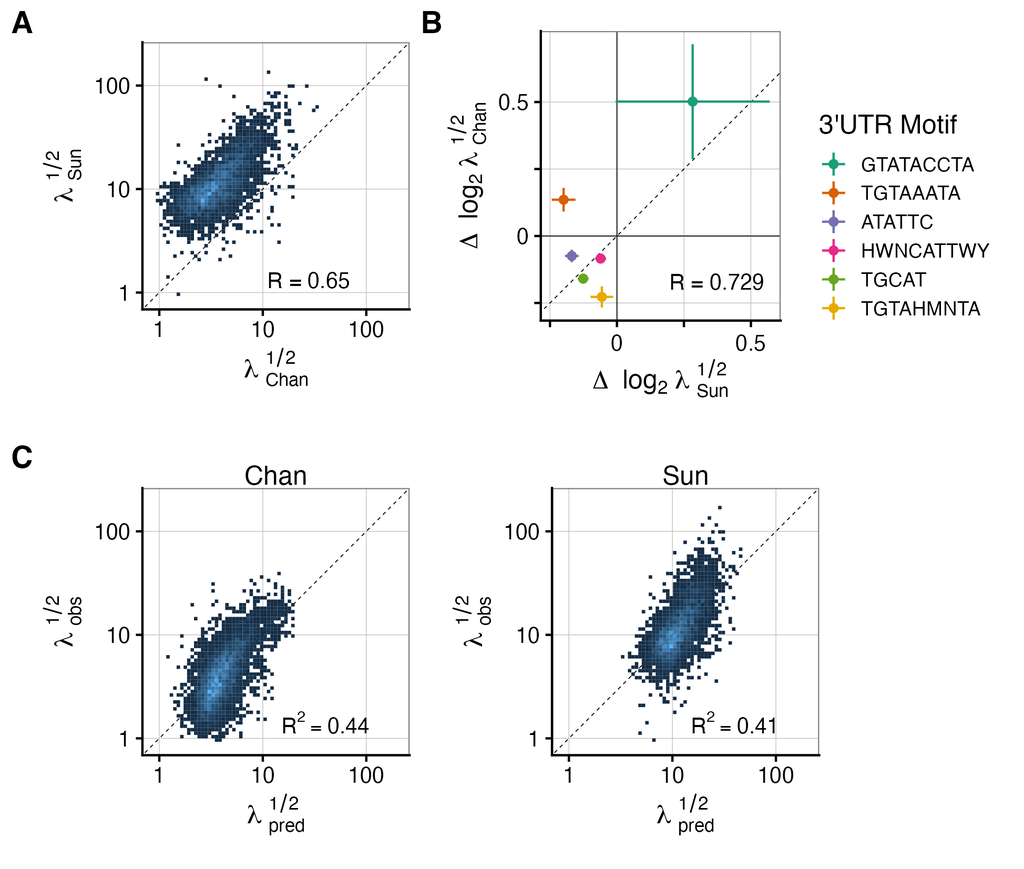

(ref:hlife-decay-model-caption)

```r
knitr::include_graphics(here("results_chapter/figures/hlife_model_multi_fig.png"))
```

## Quantification of differential expression due to motif insertion or mutagenesis in multiple 3’UTRs

To quantify the effects and composability of selected motifs in different contexts, we designed a further set of reporter constructs (Figure @ref(fig:tRPS3-tTSA1-design-and-qpcr)A). We first chose the ribosomal protein terminator tRPS3, as it was the only terminator in our initial library that did not contain any of the selected motifs. We selected thioredoxin peroxidase tTSA1 as the second host terminator because it also lacks selected motifs and has similar length to tRPS3. In each host terminator we chose 3 motif insertion sites, selecting for: minimum impact on transcript secondary structure, avoiding known transcription termination elements, and matching the positions of motifs in native genes. Having 3 insertion sites enabled us to quantify combinations of motifs, including duplicates of weaker motifs to increase the likelihood of detecting a clear effect on gene expression. We chose TGTACAATA and TTTCATTTC sequences as explicit versions of the TGTAHMNTA and HWNCATTWY consensus motifs respectively, and checked that these explicit versions have similar predicted effects on half-life transcriptome-wide (Supplementary Tables @ref(tab:HWNCATTWY-motif-coef), @ref(tab:TGTAHMNTA-motif-coef)). Altogether, 7 variant terminators were designed for these 2 host terminators: the wild-type terminator, a control to test the insertion sites with randomly generated sequences, 4 testing the effects of inserting each motif individually and a final variant to test interactions between the TGTAHMNTA and HWNCATTWY motifs. We created a construct library by pairing each terminator with three different promoters; its native promoter pairing (pRPS3 or pTSA1), the high-expression promoter pPGK1, and the low-expression promoter pSRO9.

Motifs predicted to affect half-life affect mRNA abundance when inserted into tRPS3 in reporter constructs (Figure @ref(fig:tRPS3-tTSA1-design-and-qpcr)B). We measured mRNA abundance by RT-qPCR across 6 biological replicates, each quantified in 3 technical replicates and normalised by the $\Delta Cq$ method against values from 3 reference mRNAs (see methods). Insertion of 2 copies of ATATTC (mod_NAA) generally lowers the mRNA abundance, as much as 4-fold when paired with the pRPS3 promoter. Insertion of either TGTAHMNTA (mod_NTN), or 2 copies of HWNCATTWY (mod_HNH), tends to decrease mRNA abundance, and their combined insertion (mod_HTH) tends to decrease mRNA abundance even further. The putative stability motif GTATACCTA (mod_NGG) does not consistently or strongly affect mRNA abundance. However, comparison of the WT and control (mod_NNN) terminators does show that the creation of the insertion sites alone has an effect on mRNA levels (Supplementary Table @ref(tab:insertion-construct-ttest)).

Inserting the same motifs into our second host terminator gives qualitatively similar results (Figure @ref(fig:tRPS3-tTSA1-design-and-qpcr)C). Decay motifs generally lead to decay, although ATATTC (mod_NAA) has a weaker effect in tTSA1 than in tRPS3, and TGTAHMNTA (mod_NTN) has a stronger effect in tTSA1 than tRPS3. The putative stability motif GTATACCTA (mod_NGG) again has little effect.

We confirmed that motif-dependent changes in mRNA abundance are reflected in protein abundance by measuring the fluorescence from a subset of reporter constructs with native promoter-terminator pairings (Supplementary Figure @ref(fig:protein-vs-RNA-plot-motifs)). The high correlation ($R = 0.96, 0.68, 0.86$ for tRPS3, tTSA1, tPIR1 constructs respectively) demonstrates that these combinations of decay motifs that change mRNA abundance also change the protein output, as expected.

Comparison of mRNA abundance across all constructs (Figure @ref(fig:tRPS3-tTSA1-design-and-qpcr)B, @ref(fig:tRPS3-tTSA1-design-and-qpcr)C, @ref(fig:tPIR1-design-and-qpcr)B) shows motif contributions change in magnitude but not direction depending on the context of the rest of the construct. The insertion of almost any decay motif into tTSA1 or tRPS3 results in a decrease in mRNA abundance, and removal of these from from tPIR1 results in an increase in mRNA abundance. However, the quantitative effects vary depending both on the immediate motif context in the host terminator and on the more distant context given by the promoter.

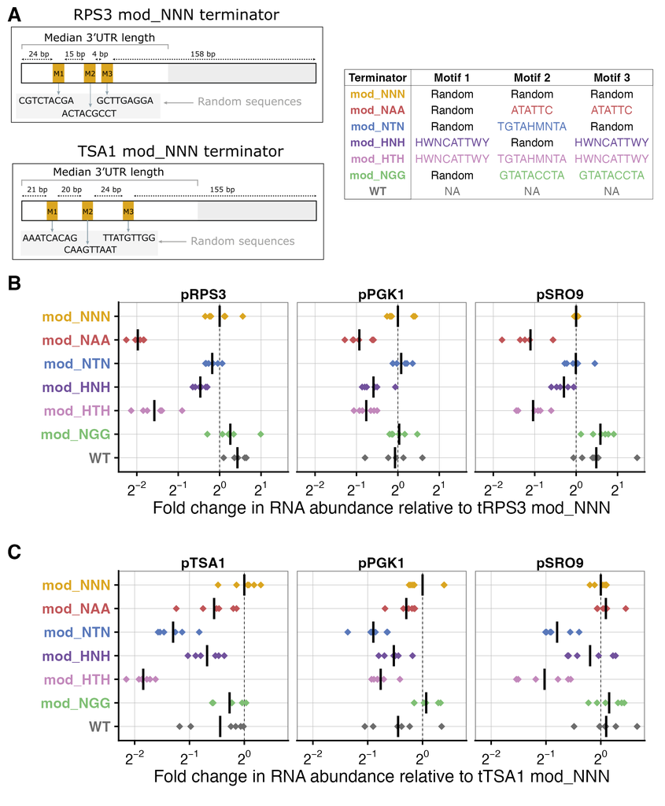

() Design of motif insertion sites in native RPS3 and TSA1 terminators, highlighting random insertion used as a negative control. () Fold changes in transcript abundance for tRPS3 constructs paired with 3 promoters: pRPS3, pPGK1 and pSRO9. () Fold changes in transcript abundance for tTSA1 constructs paired with three promoters: pTSA1, pPGK1 and pSRO9. Each diamond represents a biological replicate, averaged over 3 technical replicates. The vertical line represents the mean of all 6 biological replicates. Fold changes are relative to the abundance of the mod_NNN construct, i.e. $2^{\Delta\Delta Cq}$ (see methods).

```r
knitr::include_graphics(here("results_chapter/figures/insertion_constructs_design_and_qpcr.png"))
```

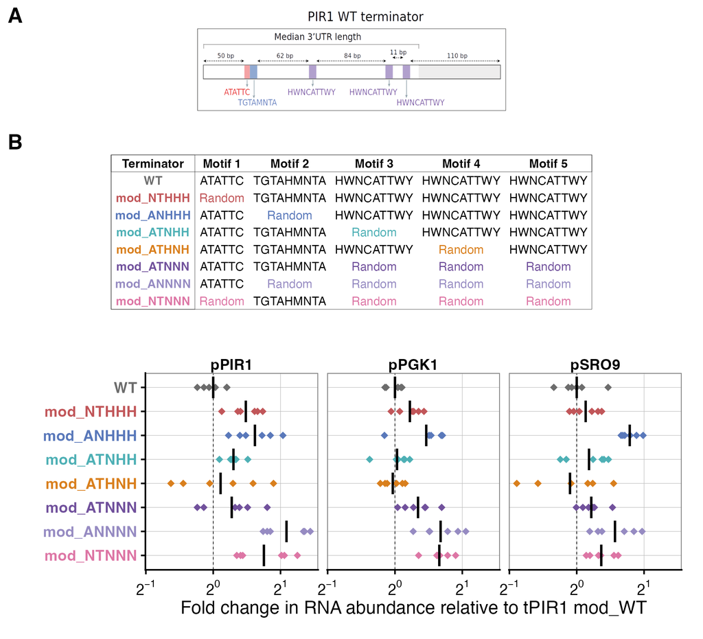

() Design of PIR1 constructs with combinations of motifs replaced by random nucleotide sequences. () Fold changes in transcript abundance for tPIR1 constructs paired with 3 promoters: pPIR1, pPGK1 and pSRO9. Each diamond represents a biological replicate, averaged over 3 technical replicates. The vertical line represents the mean of all 6 biological replicates. Fold changes are relative to the abundance of the WT construct, i.e. $2^{\Delta\Delta Cq}$ (see methods).

```r
knitr::include_graphics(here("results_chapter/figures/tPIR1_design_and_qpcr.png"))
```

## Motif effects on gene expression depend both on terminator context and promoter pairing

We compared the effects of cis-regulatory motifs on mRNA abundance to predicted effects inferred from transcriptome-wide measurements of half-life. First, we trained a linear model using the RT-qPCR results to estimate the change in log2 mRNA abundance (i.e. $\Delta Cq$) due to the presence of a motif in each promoter and terminator combination. Using a simple model of transcript production and decay, we can argue that changes in mRNA abundance are directly proportional to changes in mRNA half-life (see methods). Therefore, we compared the motif’s estimated change in log2 mRNA abundance to that predicted due to changes in log2 half-life, estimated from the Chan et al. @Chan2018 dataset. The effect of motifs in reporter constructs is correlated with the predictive model, but the strength of the correlation depends on context (Figure @ref(fig:hlife-predict-vs-abundance-and-motif-context-dependence)A). Constructs with inserted motifs (i.e. tRPS3 and tTSA1 constructs) had a lower correlation with predicted effects than constructs with deleted motifs (i.e. tPIR1 constructs). Interestingly, motif effects on mRNA abundance appear to be greater than that predicted from their effect on half-life when their host terminator is paired with its native promoter.

Comparing the estimated coefficients for each motif’s effect on mRNA abundance across promoter-terminator pairing shows that the effect of a motif depends on terminator context (Figure @ref(fig:hlife-predict-vs-abundance-and-motif-context-dependence)B). For example, ATATTCA reduces mRNA abundance substantially more when inserted in tRPS3 than in tTSA1 (pRPS3-tRPS3 log2 Fold Change = -0.99, p-value = $1.5 \times 10^{-13}$; pTSA1-tTSA1 log2 Fold Change = -0.26, p-value = $7.3 \times10^{-3}$). Meanwhile, TGTAHMNTA significantly reduces mRNA abundance when inserted in tTSA1, but not tRPS3, whichever promoter is chosen (pRPS3-tRPS3 log2 fold Change = -0.18, p-value = 0.37; pTSA1-tTSA1 log2 fold Change = -1.30, p-value = $1.0 \times10^{-7}$). Promoter choice also influences the magnitude of a motif’s contribution to mRNA levels. For the ATATTC, TGTAHMNTA and HWNCATTWY motifs the greatest reduction in mRNA abundance occurred when native promoter-terminator pairings are measured. This is true for all 3 decay motifs across all 3 host terminators, except for HWNCATTWY in pRPS3-tRPS3 constructs (Supplementary Table @ref(tab:motif-abundance-effect-table)).

Regulatory interactions between different motifs also change depending on host terminator and promoter context. We included an interaction term that quantifies how the effect of including both HWNCATTWY and TGTAHMNTA together differs from the sum of the effects of including these motifs individually. The combination of TGTAHMNTA and HWNCATTWY in tRPS3 has no significant effect beyond a simple sum of their individual effects when paired with pPGK1 (p-value = 0.39). However, when tRPS3 is paired with pRPS3 or pSRO9, the combination has a greater effect than expected from the sum of each motif’s individual effect (pRPS3 log2 fold Change = -0.47, p-value = 0.0015; pSRO9 log2 fold Change = -0.37, p-value = 0.02). The combination of TGTAHMNTA and HWNCATTWY in tTSA1 has no additional effect (pTSA1 p-value = 0.67, pSRO9 p-value = 0.91), except when paired with pPGK1, where it has a lesser effect than expected (log2 fold Change = 0.33, p-value = 0.02). Finally, the combination of TGTAHMNTA and HWNCATTWY in tPIR1 has no significant additional effect (Supplementary Table @ref(tab:motif-abundance-effect-table)).

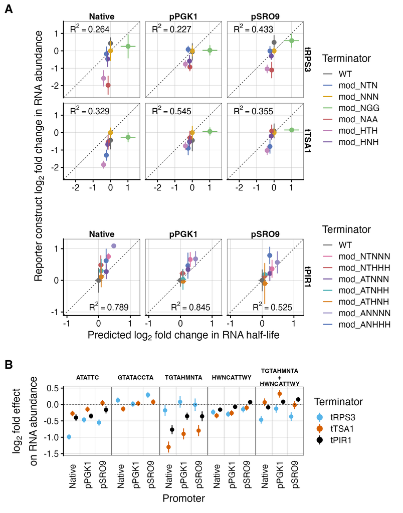

() Predicted change in transcript abundance inferred from transcriptome-wide motif contributions to half-life, compared to RT-qPCR measurements of reporter transcript abundance. The y-axis shows statistical summaries (mean and standard error) of 6 replicates for data shown in figures 4 and 5. The fold change is relative to the mod_NNN construct in each promoter-terminator pairing for the tRPS3 and tTSA1 sets, and relative to the WT constructs for tPIR1 sets. Native promoter panels show the promoter paired with the terminator from the same set, e.g. pRPS3 with tRPS3. () Motif contributions to fold changes in mRNA abundance for reporter constructs with different promoter and terminator contexts. This is calculated by a linear model with a coefficient for the effect of each motif in each set, applied to $\Delta Cq$ against 3 reference genes. The last column shows the interaction term between TGTAHMNTA and HWNCATTWY.

```r
knitr::include_graphics(here("results_chapter/figures/qPCR_model_coef_and_pred_vs_exp_abund.png"))
```

## Polyadenylation site usage depends on the terminator sequence and can be changed by motif insertion

We next mapped poly(A) site usage, across a subset of reporter strains, for 3 reasons. First, to ask if poly(A) site depends only on the terminator sequence or on the wider promoter and coding sequence context. Second, to find if motif effects on mRNA abundance could be due to changes in the poly(A) site usage. Third, to check if motifs inserted in our terminators were unintentionally absent from the mature mRNA. We performed paired-end RNA-Seq using the QuantSeq REV protocol [@Moll2014], and mapped the reads to genome sequences extended by the relevant reporter plasmid sequence (see methods). Read 1 allows precise inference of poly(A) site position while read 2 generally overlaps the CDS and allows distinguishing terminators in native loci from reporter constructs, as long as the distance between poly(A)-site and stop codon is under about 300nt and so within the sequenced fragment length. We detected 1000s of reads on each reporter construct, which is enough to quantify poly(A) sites and expression with confidence. We display the poly(A) sites as the cumulative fraction of poly(A)-site reads mapped at each location downstream of construct stop codons, out of all reads mapped to the terminator. In native genes the poly(A) site locations were highly reproducible across samples, giving us confidence that changes in reporter poly(A) sites are meaningful (Supplementary Figure @ref(fig:rnaseq-QC-QuantSeq-and-5PSeq-genomic-polyA)). We also checked that counts of native mRNAs are highly correlated between samples, giving us confidence that changes in construct detection are meaningful (Supplementary Figure @ref(fig:rnaseq-QC-correlation)).

Poly(A) sites are largely in the same positions relative to the stop codon in wild-type terminators at native genomic loci and plasmid constructs (Figure @ref(fig:rnaseq-genomic-vs-plasmid-polyA)). For plasmid-expressed terminators tPGK1, tTSA1, tRPS3, tHSP26 and tTOS6 driving mCherry expression, the major poly(A)-site is conserved and the poly(A)-site distribution is largely indistinguishable. Poly(A) sites are conserved in terminators regardless of the paired promoter, with tPGK1, tRPS3, and tTOS6 expressed downstream of pRPS3, and tTSA1 expressed paired with cognate pTSA1. The tHSP26 terminator has similar poly(A)-site distribution expressed paired with pHSP26, pRPS3, and pRPS13, although there is some termination after the major poly(A)-site in pHSP26-mCherry-tHSP26. We excluded a 420nt tPMA1 terminator from our analysis because the terminator was longer than library fragment lengths so we could not distinguish plasmid from genomic poly(A)-site reads.

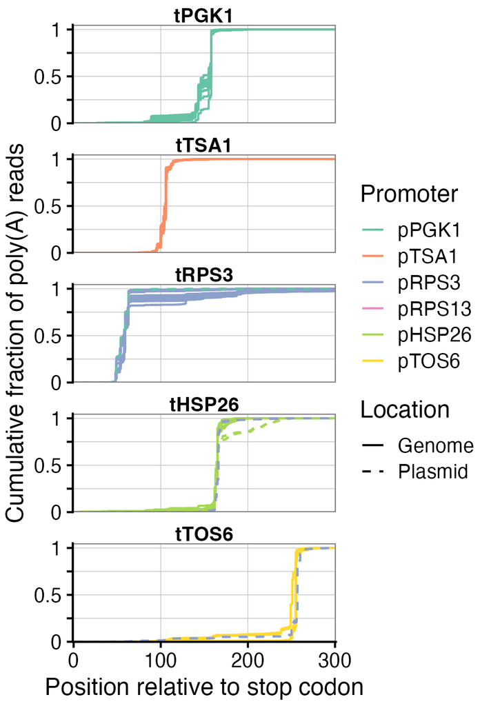

Cumulative fraction of poly(A)-site reads mapped downstream of stop codons, for native genomic terminators and selected plasmid construct terminators. Each line plots the cumulative counts of a separate replicate, with solid line for genomic copy and dashed line for plasmid-expressed copy, coloured by promoter. In some panels the dashed line indicating plasmid-mapped reads overlaps the genome-mapped reads as the cumulative distributions are not distinguishable.

```r
knitr::include_graphics(here("results_chapter/figures/plasmid_vs_genome_polyA_combined_plot.png"))
```

We then mapped poly(A)-sites for three motif insertion constructs with large effect sizes in the qPCR results: mod_NAA, mod_HTH and mod_NTN, together with WT and mod_NNN controls, within three promoter-terminator contexts: pRPS3-tRPS3, pPGK1-tRPS3 and pTSA1-tTSA1. Transcript abundance, relative to mod_NNN, for most constructs correlates strongly with qPCR results and so confirms them (Figure @ref(fig:quantseq-polyA-site-usage)A). However, some constructs were detected as differentially abundant by RNA-seq for reasons that are unclear. For example, pPGK1-tRPS3 results are skewed due to the unexpected low abundance of mod_NNN constructs in the RNA-Seq results, which all other constructs are normalised to.

Comparing the poly(A) sites in motif insertion constructs show that poly(A) site can be changed by motif insertion. We highlight the 2 major poly(A) sites for the tRPS3 constructs and 2 for the tTSA1 constructs (black vertical lines on the mod_NNN constructs in Figure @ref(fig:quantseq-polyA-site-usage)B) and track the cumulative fraction of reads upstream of each major site. In both wild-type and mod_NNN tTSA1 constructs, the relative usage of major poly(A) sites does not significantly change (Site 1 p-value = 0.068 and Site 2 p-value = 1). Surprisingly, tRPS3 mod_NNN constructs appear to be using a novel upstream poly(A) site, that appears in about $50%$ percent of reads and is located upstream of the 3rd motif insertion site (Site 1 p-value = 0.016; Figure @ref(fig:quantseq-polyA-site-usage)B). For tRPS3 constructs there is a distinct shift to downstream poly(A) sites in constructs with verified, rather than random, motifs inserted. There are also smaller differences in poly(A) site usage between constructs with different motifs (Figure @ref(fig:quantseq-polyA-site-usage)C, Supplementary Table @ref(tab:polya-usage-effect-table)). However, the poly(A) mapping results confirm that at least one copy of the motifs of interest are present in every major isoform for all constructs.

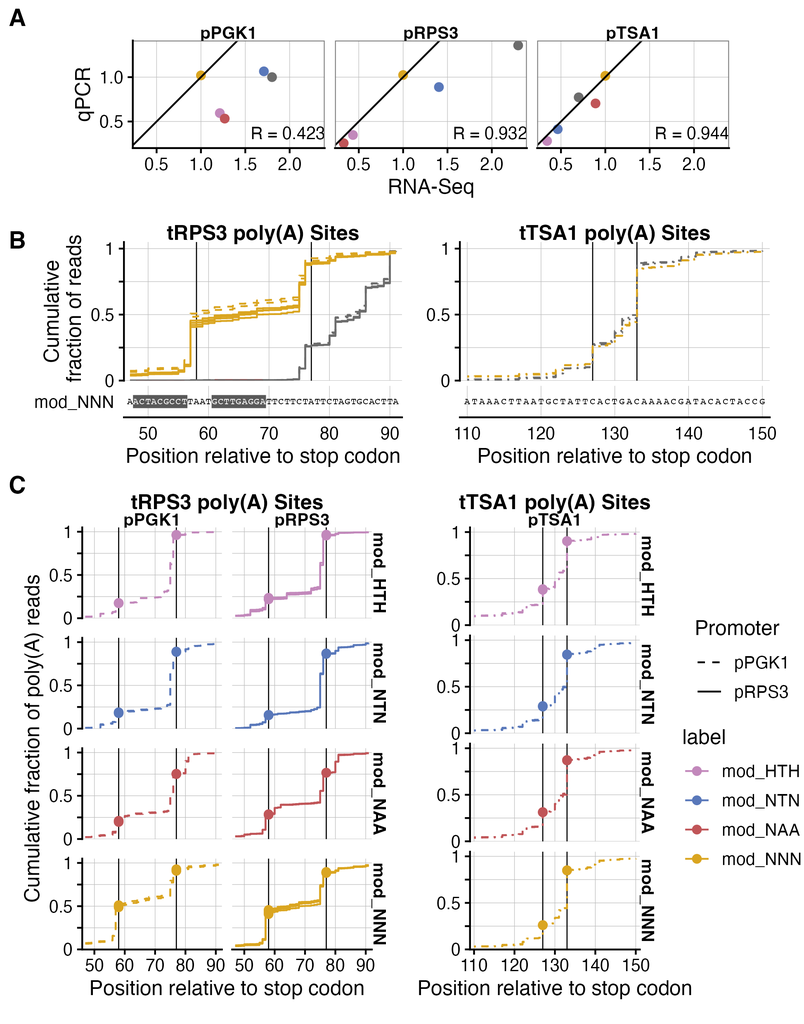

```r
knitr::include_graphics(here("results_chapter/figures/polya_usage_plot_QuantSeq.png"))
```

We then asked whether modifications in the 3’-UTR region impact 5’-3’ degradation following mRNA decapping, using the 5PSeq method targeted to the 3’-end regions of mRNA [@Pelechano2016]. 5PSeq can detect changing ribosome dynamics through 5’-3’ co-translational degradation, however, the novel modification to 5Pseq here uses an anchored oligo(dT) reverse primer so detects only the poly(A)-site proximal region of the mRNA instead of the entire coding sequence. The 5Pseq counts per gene are highly reproducible between samples (Supplementary Figure @ref(fig:rnaseq-QC-correlation)B), and the abundances of reporter mRNAs from different constructs correlate well between 5PSeq and QuantSeq data (Supplementary Figure @ref(fig:rnaseq-QC-correlation)C). Our 5PSeq data finds no detectable changes in 5’-phosphorylated intermediates between wild-type and modified reporter constructs, and thus does not indicate detectable changes in ribosome dynamics near the 3’ end of transcripts (Supplementary Figure @ref(fig:combined-5p-end-read-plot)). It does confirm the behaviour of the inserted motifs correlates with qPCR results and that an upstream alternative polyadenylation site is introduced in the tRPS3 constructs (Supplementary Figure @ref(fig:polyA-site-usage-5Pseq)). Moreover, the poly(A) site distribution for each construct matches that obtained from QuantSeq data, suggesting that 3’-UTR isoforms are not differentially degraded using this pathway regardless of the motifs inserted (Supplementary Figure @ref(fig:relative-polya-counts), Supplementary Table @ref(tab:polya-usage-effect-5PSeq-table)).

Overall, poly(A) site mapping showed that poly(A) sites depended on the terminator sequence, at most weakly on the coding sequence or promoter context, and not on the plasmid compared to genomic context. Most reporter mRNAs retained the expected poly(A) site and motifs predicted from the native terminator context, except for a new alternative poly(A) site in tRPS3 mod_NNN constructs. This was an unexpected consequence of composing cis-regulatory elements, upon introducing “random” insertions of no known function.